# Risk Factor Analysis

## Outcome Variable

**Outcome Variable:** stunted

## Predictor Variables

**Intervention Variable:** nchldlt5

**Adjustment Set:**

unadjusted

## Stratifying Variables

The analysis was stratified on these variable(s):

- agecat
- studyid
- country

## Data Summary

| agecat | studyid | country | nchldlt5 | stunted | n_cell | n |
| --- | --- | --- | --- | --- | --- | --- |
| Birth | ki1000108-IRC | INDIA | 1 | 0 | 72 | 388 |
| Birth | ki1000108-IRC | INDIA | 1 | 1 | 12 | 388 |
| Birth | ki1000108-IRC | INDIA | 2+ | 0 | 271 | 388 |
| Birth | ki1000108-IRC | INDIA | 2+ | 1 | 33 | 388 |
| Birth | ki1017093b-PROVIDE | BANGLADESH | 1 | 0 | 354 | 539 |
| Birth | ki1017093b-PROVIDE | BANGLADESH | 1 | 1 | 37 | 539 |
| Birth | ki1017093b-PROVIDE | BANGLADESH | 2+ | 0 | 137 | 539 |
| Birth | ki1017093b-PROVIDE | BANGLADESH | 2+ | 1 | 11 | 539 |
| Birth | ki1017093c-NIH-Crypto | BANGLADESH | 1 | 0 | 449 | 732 |
| Birth | ki1017093c-NIH-Crypto | BANGLADESH | 1 | 1 | 73 | 732 |
| Birth | ki1017093c-NIH-Crypto | BANGLADESH | 2+ | 0 | 182 | 732 |
| Birth | ki1017093c-NIH-Crypto | BANGLADESH | 2+ | 1 | 28 | 732 |
| Birth | kiGH5241-JiVitA-3 | BANGLADESH | 1 | 0 | 9011 | 22431 |
| Birth | kiGH5241-JiVitA-3 | BANGLADESH | 1 | 1 | 4975 | 22431 |
| Birth | kiGH5241-JiVitA-3 | BANGLADESH | 2+ | 0 | 6039 | 22431 |
| Birth | kiGH5241-JiVitA-3 | BANGLADESH | 2+ | 1 | 2406 | 22431 |
| 6 months | ki1000108-IRC | INDIA | 1 | 0 | 67 | 407 |
| 6 months | ki1000108-IRC | INDIA | 1 | 1 | 22 | 407 |
| 6 months | ki1000108-IRC | INDIA | 2+ | 0 | 240 | 407 |
| 6 months | ki1000108-IRC | INDIA | 2+ | 1 | 78 | 407 |
| 6 months | ki1017093b-PROVIDE | BANGLADESH | 1 | 0 | 368 | 604 |
| 6 months | ki1017093b-PROVIDE | BANGLADESH | 1 | 1 | 70 | 604 |
| 6 months | ki1017093b-PROVIDE | BANGLADESH | 2+ | 0 | 140 | 604 |
| 6 months | ki1017093b-PROVIDE | BANGLADESH | 2+ | 1 | 26 | 604 |
| 6 months | ki1017093c-NIH-Crypto | BANGLADESH | 1 | 0 | 400 | 715 |
| 6 months | ki1017093c-NIH-Crypto | BANGLADESH | 1 | 1 | 107 | 715 |
| 6 months | ki1017093c-NIH-Crypto | BANGLADESH | 2+ | 0 | 165 | 715 |
| 6 months | ki1017093c-NIH-Crypto | BANGLADESH | 2+ | 1 | 43 | 715 |
| 6 months | ki1066203-TanzaniaChild2 | TANZANIA, UNITED REPUBLIC OF | 1 | 0 | 1267 | 2020 |
| 6 months | ki1066203-TanzaniaChild2 | TANZANIA, UNITED REPUBLIC OF | 1 | 1 | 124 | 2020 |
| 6 months | ki1066203-TanzaniaChild2 | TANZANIA, UNITED REPUBLIC OF | 2+ | 0 | 558 | 2020 |
| 6 months | ki1066203-TanzaniaChild2 | TANZANIA, UNITED REPUBLIC OF | 2+ | 1 | 71 | 2020 |
| 6 months | ki1148112-LCNI-5 | MALAWI | 1 | 0 | 263 | 811 |
| 6 months | ki1148112-LCNI-5 | MALAWI | 1 | 1 | 127 | 811 |
| 6 months | ki1148112-LCNI-5 | MALAWI | 2+ | 0 | 253 | 811 |
| 6 months | ki1148112-LCNI-5 | MALAWI | 2+ | 1 | 168 | 811 |
| 6 months | kiGH5241-JiVitA-3 | BANGLADESH | 1 | 0 | 8093 | 16800 |
| 6 months | kiGH5241-JiVitA-3 | BANGLADESH | 1 | 1 | 2794 | 16800 |
| 6 months | kiGH5241-JiVitA-3 | BANGLADESH | 2+ | 0 | 4484 | 16800 |
| 6 months | kiGH5241-JiVitA-3 | BANGLADESH | 2+ | 1 | 1429 | 16800 |
| 24 months | ki1000108-IRC | INDIA | 1 | 0 | 58 | 409 |
| 24 months | ki1000108-IRC | INDIA | 1 | 1 | 31 | 409 |
| 24 months | ki1000108-IRC | INDIA | 2+ | 0 | 179 | 409 |
| 24 months | ki1000108-IRC | INDIA | 2+ | 1 | 141 | 409 |
| 24 months | ki1017093b-PROVIDE | BANGLADESH | 1 | 0 | 299 | 578 |
| 24 months | ki1017093b-PROVIDE | BANGLADESH | 1 | 1 | 125 | 578 |
| 24 months | ki1017093b-PROVIDE | BANGLADESH | 2+ | 0 | 89 | 578 |
| 24 months | ki1017093b-PROVIDE | BANGLADESH | 2+ | 1 | 65 | 578 |
| 24 months | ki1017093c-NIH-Crypto | BANGLADESH | 1 | 0 | 276 | 514 |
| 24 months | ki1017093c-NIH-Crypto | BANGLADESH | 1 | 1 | 81 | 514 |
| 24 months | ki1017093c-NIH-Crypto | BANGLADESH | 2+ | 0 | 106 | 514 |
| 24 months | ki1017093c-NIH-Crypto | BANGLADESH | 2+ | 1 | 51 | 514 |
| 24 months | ki1066203-TanzaniaChild2 | TANZANIA, UNITED REPUBLIC OF | 1 | 0 | 4 | 6 |
| 24 months | ki1066203-TanzaniaChild2 | TANZANIA, UNITED REPUBLIC OF | 1 | 1 | 1 | 6 |
| 24 months | ki1066203-TanzaniaChild2 | TANZANIA, UNITED REPUBLIC OF | 2+ | 0 | 1 | 6 |
| 24 months | ki1066203-TanzaniaChild2 | TANZANIA, UNITED REPUBLIC OF | 2+ | 1 | 0 | 6 |
| 24 months | ki1148112-LCNI-5 | MALAWI | 1 | 0 | 161 | 571 |
| 24 months | ki1148112-LCNI-5 | MALAWI | 1 | 1 | 122 | 571 |
| 24 months | ki1148112-LCNI-5 | MALAWI | 2+ | 0 | 158 | 571 |
| 24 months | ki1148112-LCNI-5 | MALAWI | 2+ | 1 | 130 | 571 |
| 24 months | kiGH5241-JiVitA-3 | BANGLADESH | 1 | 0 | 2889 | 8622 |
| 24 months | kiGH5241-JiVitA-3 | BANGLADESH | 1 | 1 | 2565 | 8622 |
| 24 months | kiGH5241-JiVitA-3 | BANGLADESH | 2+ | 0 | 1499 | 8622 |
| 24 months | kiGH5241-JiVitA-3 | BANGLADESH | 2+ | 1 | 1669 | 8622 |

The following strata were considered:

- agecat: 24 months, studyid: ki1000108-IRC, country: INDIA
- agecat: 24 months, studyid: ki1017093b-PROVIDE, country: BANGLADESH
- agecat: 24 months, studyid: ki1017093c-NIH-Crypto, country: BANGLADESH
- agecat: 24 months, studyid: ki1066203-TanzaniaChild2, country: TANZANIA, UNITED REPUBLIC OF
- agecat: 24 months, studyid: ki1148112-LCNI-5, country: MALAWI
- agecat: 24 months, studyid: kiGH5241-JiVitA-3, country: BANGLADESH
- agecat: 6 months, studyid: ki1000108-IRC, country: INDIA
- agecat: 6 months, studyid: ki1017093b-PROVIDE, country: BANGLADESH
- agecat: 6 months, studyid: ki1017093c-NIH-Crypto, country: BANGLADESH
- agecat: 6 months, studyid: ki1066203-TanzaniaChild2, country: TANZANIA, UNITED REPUBLIC OF
- agecat: 6 months, studyid: ki1148112-LCNI-5, country: MALAWI
- agecat: 6 months, studyid: kiGH5241-JiVitA-3, country: BANGLADESH
- agecat: Birth, studyid: ki1000108-IRC, country: INDIA
- agecat: Birth, studyid: ki1017093b-PROVIDE, country: BANGLADESH
- agecat: Birth, studyid: ki1017093c-NIH-Crypto, country: BANGLADESH
- agecat: Birth, studyid: kiGH5241-JiVitA-3, country: BANGLADESH

### Dropped Strata

Some strata were dropped due to rare outcomes:

- agecat: 24 months, studyid: ki1066203-TanzaniaChild2, country: TANZANIA, UNITED REPUBLIC OF

## Methods Detail

We’re interested in the causal parameters $E[Y_a]$ for all values of $a \in \mathcal{A}$. These parameters represent the mean outcome if, possibly contrary to fact, we intervened to set all units to have $A=a$. Under the randomization and positivity assumptions, these are identified by the statistical parameters $\psi_a=E_W[E_{Y|A,W}(Y|A=a,W)]$. In addition, we’re interested in the mean of $Y$, $E[Y]$ under no intervention (the observed mean). We will estimate these parameters by using SuperLearner to fit the relevant likelihood factors – $E_{Y|A,W}(Y|A=a,W)$ and $p(A=a|W)$, and then updating our likelihood fit using a joint TMLE.

For unadjusted analyses ($W=\{\}$), initial likelihoods were estimated using Lrnr_glm to estimate the simple $E(Y|A)$ and Lrnr_mean to estimate $p(A)$. For adjusted analyses, a small library containing Lrnr_glmnet, Lrnr_xgboost, and Lrnr_mean was used.

Having estimated these parameters, we will then use the delta method to estimate relative risks and attributable risks relative to a prespecified baseline level of $A$.

# Results Detail

## Results Plots

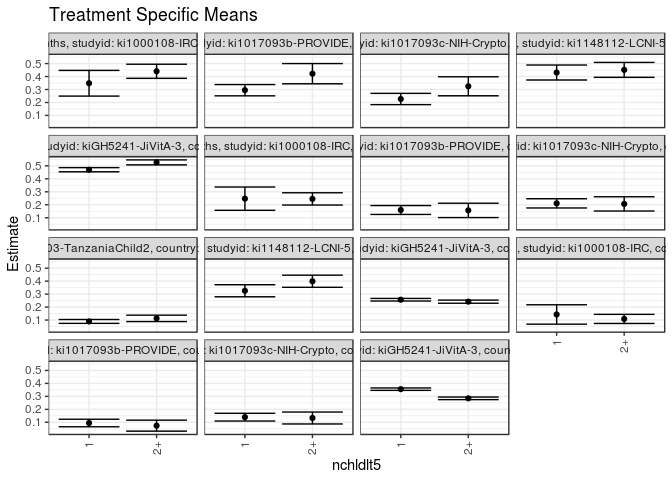

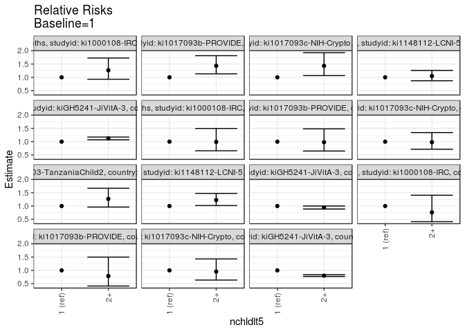

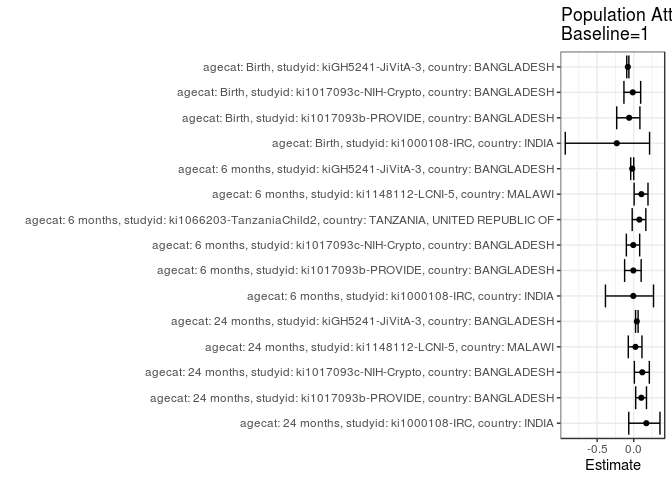

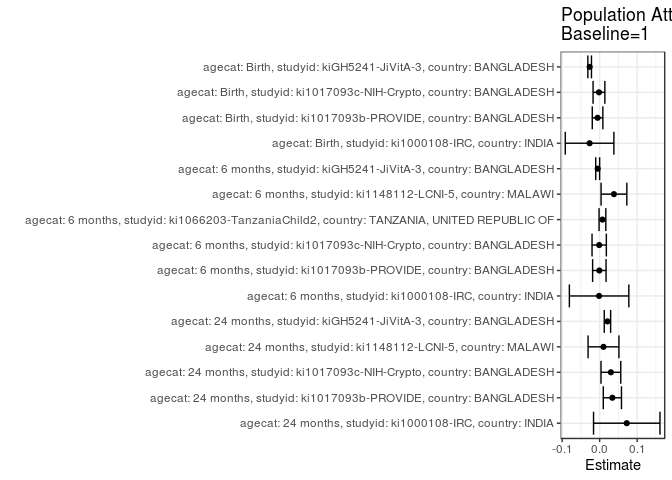

## Results Table

### Parameter: TSM

| agecat | studyid | country | intervention_level | baseline_level | estimate | ci_lower | ci_upper |
| --- | --- | --- | --- | --- | --- | --- | --- |
| Birth | ki1000108-IRC | INDIA | 1 | NA | 0.1428571 | 0.0679288 | 0.2177855 |
| Birth | ki1000108-IRC | INDIA | 2+ | NA | 0.1085526 | 0.0735388 | 0.1435665 |
| Birth | ki1017093b-PROVIDE | BANGLADESH | 1 | NA | 0.0946292 | 0.0655897 | 0.1236686 |
| Birth | ki1017093b-PROVIDE | BANGLADESH | 2+ | NA | 0.0743243 | 0.0320268 | 0.1166219 |
| Birth | ki1017093c-NIH-Crypto | BANGLADESH | 1 | NA | 0.1398467 | 0.1100737 | 0.1696198 |
| Birth | ki1017093c-NIH-Crypto | BANGLADESH | 2+ | NA | 0.1333333 | 0.0873256 | 0.1793411 |
| Birth | kiGH5241-JiVitA-3 | BANGLADESH | 1 | NA | 0.3557129 | 0.3463568 | 0.3650689 |
| Birth | kiGH5241-JiVitA-3 | BANGLADESH | 2+ | NA | 0.2849023 | 0.2748921 | 0.2949125 |
| 6 months | ki1000108-IRC | INDIA | 1 | NA | 0.2471910 | 0.1574593 | 0.3369227 |
| 6 months | ki1000108-IRC | INDIA | 2+ | NA | 0.2452830 | 0.1979358 | 0.2926302 |
| 6 months | ki1017093b-PROVIDE | BANGLADESH | 1 | NA | 0.1598174 | 0.1254719 | 0.1941628 |
| 6 months | ki1017093b-PROVIDE | BANGLADESH | 2+ | NA | 0.1566265 | 0.1012919 | 0.2119611 |
| 6 months | ki1017093c-NIH-Crypto | BANGLADESH | 1 | NA | 0.2110454 | 0.1755017 | 0.2465890 |
| 6 months | ki1017093c-NIH-Crypto | BANGLADESH | 2+ | NA | 0.2067308 | 0.1516585 | 0.2618031 |
| 6 months | ki1066203-TanzaniaChild2 | TANZANIA, UNITED REPUBLIC OF | 1 | NA | 0.0891445 | 0.0741661 | 0.1041229 |
| 6 months | ki1066203-TanzaniaChild2 | TANZANIA, UNITED REPUBLIC OF | 2+ | NA | 0.1128776 | 0.0881418 | 0.1376134 |
| 6 months | ki1148112-LCNI-5 | MALAWI | 1 | NA | 0.3256410 | 0.2791040 | 0.3721781 |
| 6 months | ki1148112-LCNI-5 | MALAWI | 2+ | NA | 0.3990499 | 0.3522432 | 0.4458566 |
| 6 months | kiGH5241-JiVitA-3 | BANGLADESH | 1 | NA | 0.2566364 | 0.2466681 | 0.2666046 |
| 6 months | kiGH5241-JiVitA-3 | BANGLADESH | 2+ | NA | 0.2416709 | 0.2295775 | 0.2537643 |
| 24 months | ki1000108-IRC | INDIA | 1 | NA | 0.3483146 | 0.2492110 | 0.4474182 |
| 24 months | ki1000108-IRC | INDIA | 2+ | NA | 0.4406250 | 0.3861634 | 0.4950866 |
| 24 months | ki1017093b-PROVIDE | BANGLADESH | 1 | NA | 0.2948113 | 0.2513737 | 0.3382489 |
| 24 months | ki1017093b-PROVIDE | BANGLADESH | 2+ | NA | 0.4220779 | 0.3440060 | 0.5001498 |
| 24 months | ki1017093c-NIH-Crypto | BANGLADESH | 1 | NA | 0.2268908 | 0.1834031 | 0.2703784 |
| 24 months | ki1017093c-NIH-Crypto | BANGLADESH | 2+ | NA | 0.3248408 | 0.2515145 | 0.3981670 |
| 24 months | ki1148112-LCNI-5 | MALAWI | 1 | NA | 0.4310954 | 0.3733467 | 0.4888441 |
| 24 months | ki1148112-LCNI-5 | MALAWI | 2+ | NA | 0.4513889 | 0.3938661 | 0.5089117 |
| 24 months | kiGH5241-JiVitA-3 | BANGLADESH | 1 | NA | 0.4702970 | 0.4543221 | 0.4862720 |
| 24 months | kiGH5241-JiVitA-3 | BANGLADESH | 2+ | NA | 0.5268308 | 0.5078037 | 0.5458580 |

### Parameter: E(Y)

| agecat | studyid | country | intervention_level | baseline_level | estimate | ci_lower | ci_upper |
| --- | --- | --- | --- | --- | --- | --- | --- |
| Birth | ki1000108-IRC | INDIA | NA | NA | 0.1159794 | 0.0840777 | 0.1478811 |
| Birth | ki1017093b-PROVIDE | BANGLADESH | NA | NA | 0.0890538 | 0.0649864 | 0.1131212 |
| Birth | ki1017093c-NIH-Crypto | BANGLADESH | NA | NA | 0.1379781 | 0.1129774 | 0.1629789 |
| Birth | kiGH5241-JiVitA-3 | BANGLADESH | NA | NA | 0.3290535 | 0.3216788 | 0.3364283 |
| 6 months | ki1000108-IRC | INDIA | NA | NA | 0.2457002 | 0.2038248 | 0.2875757 |
| 6 months | ki1017093b-PROVIDE | BANGLADESH | NA | NA | 0.1589404 | 0.1297581 | 0.1881227 |
| 6 months | ki1017093c-NIH-Crypto | BANGLADESH | NA | NA | 0.2097902 | 0.1799252 | 0.2396552 |
| 6 months | ki1066203-TanzaniaChild2 | TANZANIA, UNITED REPUBLIC OF | NA | NA | 0.0965347 | 0.0836528 | 0.1094165 |
| 6 months | ki1148112-LCNI-5 | MALAWI | NA | NA | 0.3637485 | 0.3306185 | 0.3968784 |
| 6 months | kiGH5241-JiVitA-3 | BANGLADESH | NA | NA | 0.2513690 | 0.2432434 | 0.2594947 |
| 24 months | ki1000108-IRC | INDIA | NA | NA | 0.4205379 | 0.3726382 | 0.4684376 |
| 24 months | ki1017093b-PROVIDE | BANGLADESH | NA | NA | 0.3287197 | 0.2903909 | 0.3670485 |
| 24 months | ki1017093c-NIH-Crypto | BANGLADESH | NA | NA | 0.2568093 | 0.2190047 | 0.2946140 |
| 24 months | ki1148112-LCNI-5 | MALAWI | NA | NA | 0.4413310 | 0.4005676 | 0.4820944 |
| 24 months | kiGH5241-JiVitA-3 | BANGLADESH | NA | NA | 0.4910694 | 0.4779621 | 0.5041766 |

### Parameter: RR

| agecat | studyid | country | intervention_level | baseline_level | estimate | ci_lower | ci_upper |
| --- | --- | --- | --- | --- | --- | --- | --- |
| Birth | ki1000108-IRC | INDIA | 1 | 1 | 1.0000000 | 1.0000000 | 1.0000000 |
| Birth | ki1000108-IRC | INDIA | 2+ | 1 | 0.7598684 | 0.4105111 | 1.4065393 |
| Birth | ki1017093b-PROVIDE | BANGLADESH | 1 | 1 | 1.0000000 | 1.0000000 | 1.0000000 |
| Birth | ki1017093b-PROVIDE | BANGLADESH | 2+ | 1 | 0.7854273 | 0.4114413 | 1.4993538 |
| Birth | ki1017093c-NIH-Crypto | BANGLADESH | 1 | 1 | 1.0000000 | 1.0000000 | 1.0000000 |
| Birth | ki1017093c-NIH-Crypto | BANGLADESH | 2+ | 1 | 0.9534247 | 0.6356254 | 1.4301168 |
| Birth | kiGH5241-JiVitA-3 | BANGLADESH | 1 | 1 | 1.0000000 | 1.0000000 | 1.0000000 |
| Birth | kiGH5241-JiVitA-3 | BANGLADESH | 2+ | 1 | 0.8009334 | 0.7687254 | 0.8344909 |
| 6 months | ki1000108-IRC | INDIA | 1 | 1 | 1.0000000 | 1.0000000 | 1.0000000 |
| 6 months | ki1000108-IRC | INDIA | 2+ | 1 | 0.9922813 | 0.6577791 | 1.4968888 |
| 6 months | ki1017093b-PROVIDE | BANGLADESH | 1 | 1 | 1.0000000 | 1.0000000 | 1.0000000 |
| 6 months | ki1017093b-PROVIDE | BANGLADESH | 2+ | 1 | 0.9800344 | 0.6481155 | 1.4819387 |
| 6 months | ki1017093c-NIH-Crypto | BANGLADESH | 1 | 1 | 1.0000000 | 1.0000000 | 1.0000000 |
| 6 months | ki1017093c-NIH-Crypto | BANGLADESH | 2+ | 1 | 0.9795561 | 0.7147486 | 1.3424722 |
| 6 months | ki1066203-TanzaniaChild2 | TANZANIA, UNITED REPUBLIC OF | 1 | 1 | 1.0000000 | 1.0000000 | 1.0000000 |
| 6 months | ki1066203-TanzaniaChild2 | TANZANIA, UNITED REPUBLIC OF | 2+ | 1 | 1.2662316 | 0.9606982 | 1.6689346 |
| 6 months | ki1148112-LCNI-5 | MALAWI | 1 | 1 | 1.0000000 | 1.0000000 | 1.0000000 |
| 6 months | ki1148112-LCNI-5 | MALAWI | 2+ | 1 | 1.2254288 | 1.0185798 | 1.4742838 |
| 6 months | kiGH5241-JiVitA-3 | BANGLADESH | 1 | 1 | 1.0000000 | 1.0000000 | 1.0000000 |
| 6 months | kiGH5241-JiVitA-3 | BANGLADESH | 2+ | 1 | 0.9416861 | 0.8871167 | 0.9996123 |
| 24 months | ki1000108-IRC | INDIA | 1 | 1 | 1.0000000 | 1.0000000 | 1.0000000 |
| 24 months | ki1000108-IRC | INDIA | 2+ | 1 | 1.2650202 | 0.9276297 | 1.7251237 |
| 24 months | ki1017093b-PROVIDE | BANGLADESH | 1 | 1 | 1.0000000 | 1.0000000 | 1.0000000 |
| 24 months | ki1017093b-PROVIDE | BANGLADESH | 2+ | 1 | 1.4316883 | 1.1301761 | 1.8136389 |
| 24 months | ki1017093c-NIH-Crypto | BANGLADESH | 1 | 1 | 1.0000000 | 1.0000000 | 1.0000000 |
| 24 months | ki1017093c-NIH-Crypto | BANGLADESH | 2+ | 1 | 1.4317056 | 1.0647507 | 1.9251275 |
| 24 months | ki1148112-LCNI-5 | MALAWI | 1 | 1 | 1.0000000 | 1.0000000 | 1.0000000 |
| 24 months | ki1148112-LCNI-5 | MALAWI | 2+ | 1 | 1.0470742 | 0.8703233 | 1.2597209 |
| 24 months | kiGH5241-JiVitA-3 | BANGLADESH | 1 | 1 | 1.0000000 | 1.0000000 | 1.0000000 |
| 24 months | kiGH5241-JiVitA-3 | BANGLADESH | 2+ | 1 | 1.1202087 | 1.0696631 | 1.1731427 |

### Parameter: PAR

| agecat | studyid | country | intervention_level | baseline_level | estimate | ci_lower | ci_upper |
| --- | --- | --- | --- | --- | --- | --- | --- |
| Birth | ki1000108-IRC | INDIA | 1 | NA | -0.0268778 | -0.0916934 | 0.0379379 |
| Birth | ki1017093b-PROVIDE | BANGLADESH | 1 | NA | -0.0055754 | -0.0196841 | 0.0085334 |
| Birth | ki1017093c-NIH-Crypto | BANGLADESH | 1 | NA | -0.0018686 | -0.0175916 | 0.0138544 |
| Birth | kiGH5241-JiVitA-3 | BANGLADESH | 1 | NA | -0.0266593 | -0.0314730 | -0.0218456 |
| 6 months | ki1000108-IRC | INDIA | 1 | NA | -0.0014908 | -0.0807619 | 0.0777804 |
| 6 months | ki1017093b-PROVIDE | BANGLADESH | 1 | NA | -0.0008770 | -0.0187765 | 0.0170225 |
| 6 months | ki1017093c-NIH-Crypto | BANGLADESH | 1 | NA | -0.0012552 | -0.0203237 | 0.0178134 |
| 6 months | ki1066203-TanzaniaChild2 | TANZANIA, UNITED REPUBLIC OF | 1 | NA | 0.0073902 | -0.0016270 | 0.0164074 |
| 6 months | ki1148112-LCNI-5 | MALAWI | 1 | NA | 0.0381074 | 0.0037508 | 0.0724640 |
| 6 months | kiGH5241-JiVitA-3 | BANGLADESH | 1 | NA | -0.0052673 | -0.0104675 | -0.0000671 |
| 24 months | ki1000108-IRC | INDIA | 1 | NA | 0.0722233 | -0.0163290 | 0.1607756 |
| 24 months | ki1017093b-PROVIDE | BANGLADESH | 1 | NA | 0.0339084 | 0.0096658 | 0.0581511 |
| 24 months | ki1017093c-NIH-Crypto | BANGLADESH | 1 | NA | 0.0299186 | 0.0035875 | 0.0562496 |
| 24 months | ki1148112-LCNI-5 | MALAWI | 1 | NA | 0.0102356 | -0.0308844 | 0.0513556 |
| 24 months | kiGH5241-JiVitA-3 | BANGLADESH | 1 | NA | 0.0207723 | 0.0122766 | 0.0292681 |

### Parameter: PAF

| agecat | studyid | country | intervention_level | baseline_level | estimate | ci_lower | ci_upper |
| --- | --- | --- | --- | --- | --- | --- | --- |
| Birth | ki1000108-IRC | INDIA | 1 | NA | -0.2317460 | -0.9350634 | 0.2159439 |
| Birth | ki1017093b-PROVIDE | BANGLADESH | 1 | NA | -0.0626066 | -0.2326232 | 0.0839595 |
| Birth | ki1017093c-NIH-Crypto | BANGLADESH | 1 | NA | -0.0135427 | -0.1341288 | 0.0942220 |
| Birth | kiGH5241-JiVitA-3 | BANGLADESH | 1 | NA | -0.0810182 | -0.0956015 | -0.0666289 |
| 6 months | ki1000108-IRC | INDIA | 1 | NA | -0.0060674 | -0.3864361 | 0.2699471 |
| 6 months | ki1017093b-PROVIDE | BANGLADESH | 1 | NA | -0.0055175 | -0.1246808 | 0.1010201 |
| 6 months | ki1017093c-NIH-Crypto | BANGLADESH | 1 | NA | -0.0059829 | -0.1011070 | 0.0809234 |
| 6 months | ki1066203-TanzaniaChild2 | TANZANIA, UNITED REPUBLIC OF | 1 | NA | 0.0765544 | -0.0212450 | 0.1649881 |
| 6 months | ki1148112-LCNI-5 | MALAWI | 1 | NA | 0.1047631 | 0.0051365 | 0.1944131 |
| 6 months | kiGH5241-JiVitA-3 | BANGLADESH | 1 | NA | -0.0209545 | -0.0418128 | -0.0005138 |
| 24 months | ki1000108-IRC | INDIA | 1 | NA | 0.1717403 | -0.0682523 | 0.3578163 |
| 24 months | ki1017093b-PROVIDE | BANGLADESH | 1 | NA | 0.1031529 | 0.0264168 | 0.1738409 |
| 24 months | ki1017093c-NIH-Crypto | BANGLADESH | 1 | NA | 0.1165011 | 0.0084119 | 0.2128080 |
| 24 months | ki1148112-LCNI-5 | MALAWI | 1 | NA | 0.0231926 | -0.0745832 | 0.1120718 |
| 24 months | kiGH5241-JiVitA-3 | BANGLADESH | 1 | NA | 0.0423002 | 0.0247473 | 0.0595372 |